# Diagnosis

María Sánchez Paniagua

2024-04-28

# 1 Ejercicios del libro de Faraway

## 1.1 1. (Ejercicio 1 cap. 6 pág. 97)

Using the sat dataset, fit a model with the total SAT score as the response and expend, salary, ratio and takers as predictors. Perform regression diagnostics on this model to answer the following questions. Display any plots that are relevant. Do not provide any plots about which you have nothing to say. Suggest possible improvements or corrections to the model where appropriate.

```r
library(faraway)
data(sat)
dim(sat)
```

```
## [1] 50  7
```

```r
model <- lm(total ~ expend + salary + ratio + takers, data = sat)

summary(model)
```

```
##
## Call:
## lm(formula = total ~ expend + salary + ratio + takers, data = sat)
##
## Residuals:
##     Min      1Q  Median      3Q     Max
## -90.531 -20.855  -1.746  15.979  66.571
##
## Coefficients:
##              Estimate Std. Error t value Pr(>|t|)
## (Intercept) 1045.9715    52.8698  19.784  < 2e-16 ***
## expend         4.4626    10.5465   0.423    0.674
## salary         1.6379     2.3872   0.686    0.496
## ratio         -3.6242     3.2154  -1.127    0.266
## takers        -2.9045     0.2313 -12.559 2.61e-16 ***
## ---
## Signif. codes:  0 '***' 0.001 '**' 0.01 '*' 0.05 '.' 0.1 ' ' 1
##
## Residual standard error: 32.7 on 45 degrees of freedom
## Multiple R-squared:  0.8246, Adjusted R-squared:  0.809
## F-statistic: 52.88 on 4 and 45 DF,  p-value: < 2.2e-16
```

El datasaet tiene 50 observaciones. En los siguientes gráficos podremos observar si la varianza es constante y si hay algún tipo de no linearidad.

1. Check the constant variance assumption for the errors.

Se generan diferentes gráficos en los que se pueden observar diferentes casos de no sontancia de varianza:

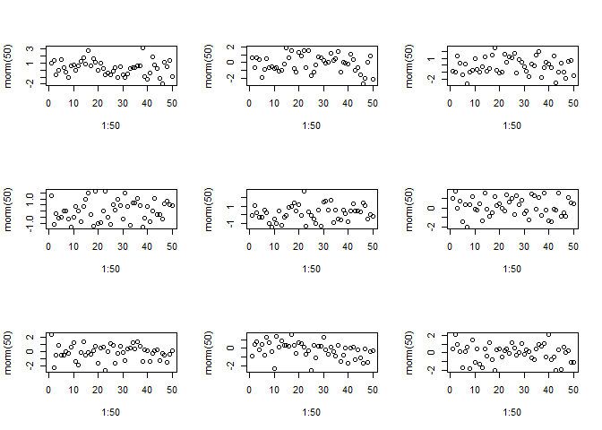

```r
par(mfrow=c(3,3))
for(i in 1:9) plot(1:50,rnorm(50))              # constant variance
```

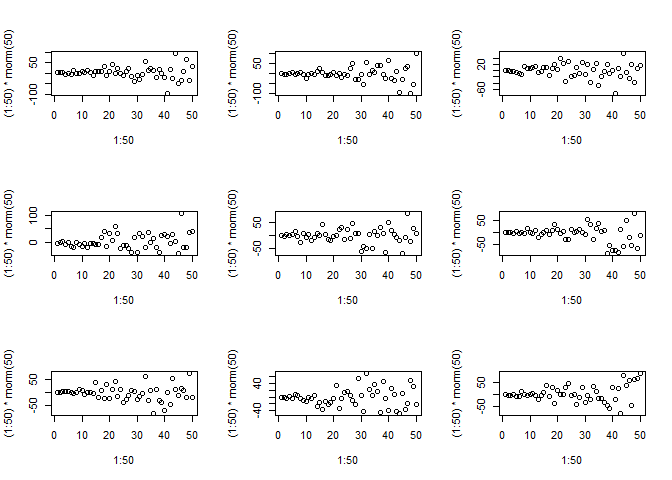

```r
for(i in 1:9) plot(1:50,(1:50)*rnorm(50))       # strong heterogeneity
```

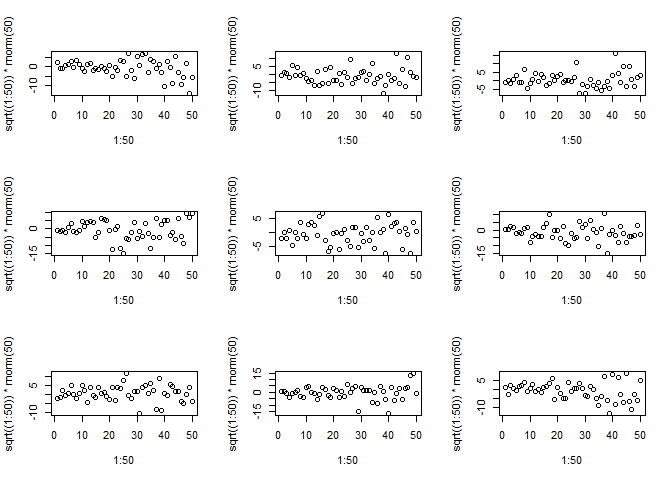

```r
for(i in 1:9) plot(1:50,sqrt((1:50))*rnorm(50)) # mild heterogeneity
```

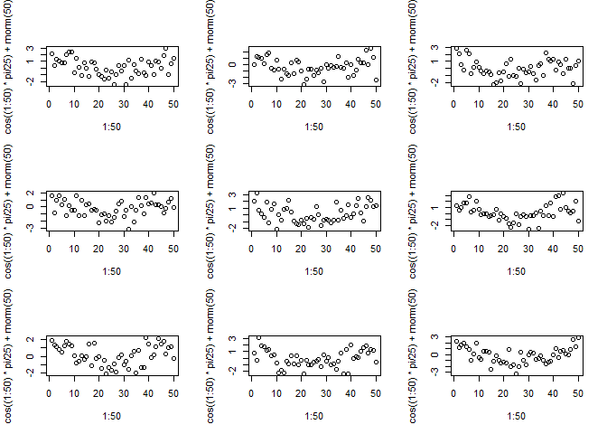

```r
for(i in 1:9) plot(1:50,cos((1:50)*pi/25)+rnorm(50)) # non-linearity
```

En primer lugar se observan los valores de los residuos y los predichos para ver la varianza de los errores.

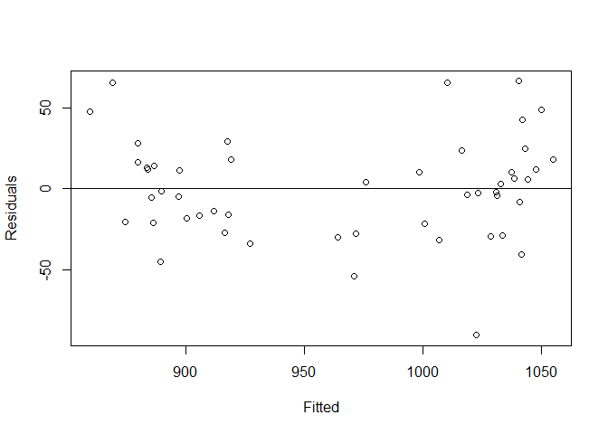

```r
plot(fitted(model), residuals(model), xlab = "Fitted", ylab = "Residuals")
abline(h=0)
```

Se puede observar que hay cierta asimetría en la distribución de los residuos.

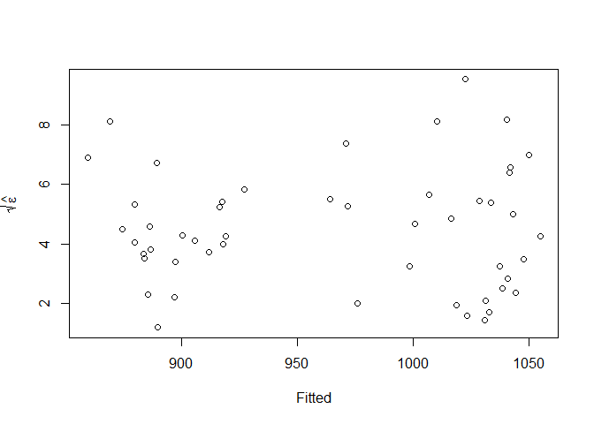

```r
plot(fitted(model), sqrt(abs(residuals(model))), xlab = "Fitted", ylab = expression(sqrt(hat(epsilon))))
```

En esta distribución se observa cierta corrección de asimetría en la varianza de los errores.

Para ver de forma más clara la varianza de los errores, se puede hacer un análisis de regresión de la raiz cuadrada de los residuos frente a los valores ajustados.

```r
summary(lm(sqrt(abs(residuals(model))) ~ fitted(model)))
```

```
##
## Call:
## lm(formula = sqrt(abs(residuals(model))) ~ fitted(model))
##
## Residuals:
##     Min      1Q  Median      3Q     Max
## -3.3097 -1.2366 -0.2234  0.9929  5.0337
##
## Coefficients:
##                 Estimate Std. Error t value Pr(>|t|)
## (Intercept)    4.6484524  4.0660807   1.143    0.259
## fitted(model) -0.0001637  0.0041994  -0.039    0.969
##
## Residual standard error: 1.997 on 48 degrees of freedom
## Multiple R-squared:  3.166e-05,  Adjusted R-squared:  -0.0208
## F-statistic: 0.00152 on 1 and 48 DF,  p-value: 0.9691
```

Si nos fijamos en los coeficientes, ninguno de éstos es estadísticamente significativo. El valo de R^2 es bastante bajo, lo que indica que el modelo no es adecuado para explicar la varianza de los errores. El estadístico F y su p-valor indican que el modelo no es significativo.

Podría utilizarse alguna transformación no lineal

```r
model <- lm(sqrt(total) ~ expend + salary + ratio + takers, data = sat)
summary(model)
```

```
##
## Call:
## lm(formula = sqrt(total) ~ expend + salary + ratio + takers,
##     data = sat)
##
## Residuals:
##      Min       1Q   Median       3Q      Max
## -1.43610 -0.34707 -0.02486  0.25943  1.08084
##
## Coefficients:
##              Estimate Std. Error t value Pr(>|t|)
## (Intercept) 32.297536   0.840140  38.443   <2e-16 ***
## expend       0.075430   0.167592   0.450    0.655
## salary       0.026203   0.037935   0.691    0.493
## ratio       -0.056489   0.051095  -1.106    0.275
## takers      -0.046730   0.003675 -12.716   <2e-16 ***
## ---
## Signif. codes:  0 '***' 0.001 '**' 0.01 '*' 0.05 '.' 0.1 ' ' 1
##
## Residual standard error: 0.5197 on 45 degrees of freedom
## Multiple R-squared:  0.8278, Adjusted R-squared:  0.8125
## F-statistic: 54.08 on 4 and 45 DF,  p-value: < 2.2e-16
```

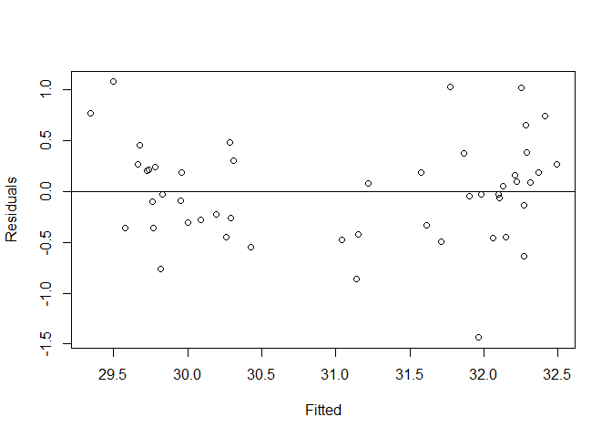

```r
plot(fitted(model), residuals(model), xlab = "Fitted", ylab = "Residuals")
abline(h=0)
```

La transformación de la variable respuesta ha mejorado lie¡geramente el R cuadrado.

A continuación se viseualizan los residuos contra los predictores individuales, para ver si hay alguna relación entre el error y las variables independientes

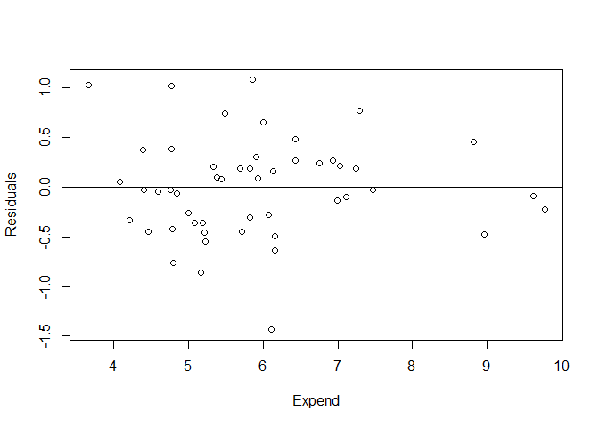

```r
plot(sat$expend, residuals(model), xlab = "Expend", ylab = "Residuals")
abline(h=0)
```

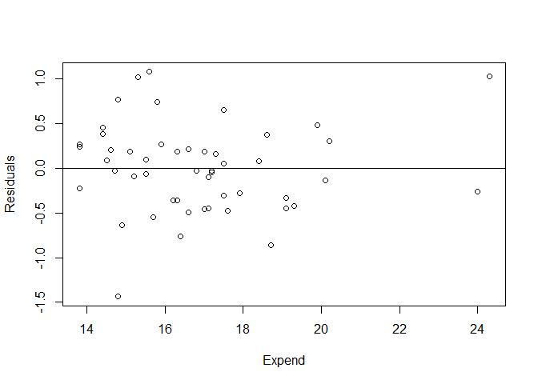

```r
plot(sat$ratio, residuals(model), xlab = "Expend", ylab = "Residuals")
abline(h=0)
```

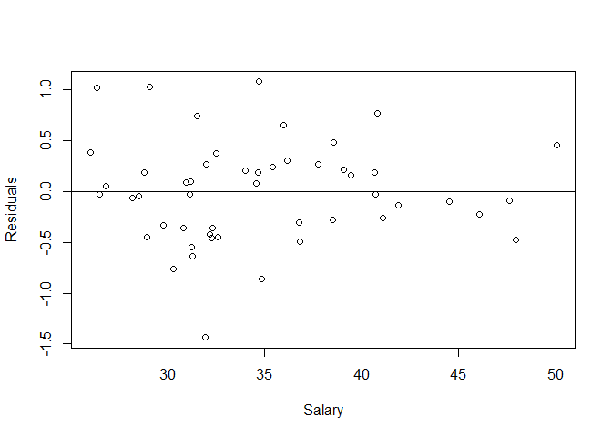

```r
plot(sat$salary, residuals(model), xlab = "Salary", ylab = "Residuals")
abline(h=0)
```

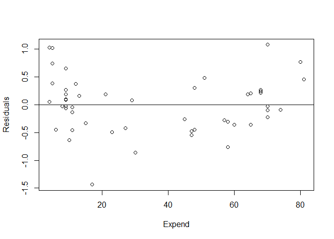

```r
plot(sat$takers, residuals(model), xlab = "Expend", ylab = "Residuals")
abline(h=0)
```

Tambbién podria considerarse comparar la varianza entre los dos grupos:

```r
var.test(residuals(model)[sat$expend>6], residuals(model)[sat$exp<6])
```

```
##
##  F test to compare two variances
##
## data:  residuals(model)[sat$expend > 6] and residuals(model)[sat$exp < 6]
## F = 0.97902, num df = 18, denom df = 29, p-value = 0.9872
## alternative hypothesis: true ratio of variances is not equal to 1
## 95 percent confidence interval:
##  0.4348856 2.4012045
## sample estimates:
## ratio of variances
##           0.979024
```

```r
var.test(residuals(model)[sat$takers>40], residuals(model)[sat$takers<40])
```

```
##
##  F test to compare two variances
##
## data:  residuals(model)[sat$takers > 40] and residuals(model)[sat$takers < 40]
## F = 0.67672, num df = 22, denom df = 26, p-value = 0.3555
## alternative hypothesis: true ratio of variances is not equal to 1
## 95 percent confidence interval:
##  0.3015332 1.5624351
## sample estimates:
## ratio of variances
##          0.6767225
```

No hay diferencias significativas entre los grupos.

2. Check the normality assumption.

Primero se comprueba graficamente:

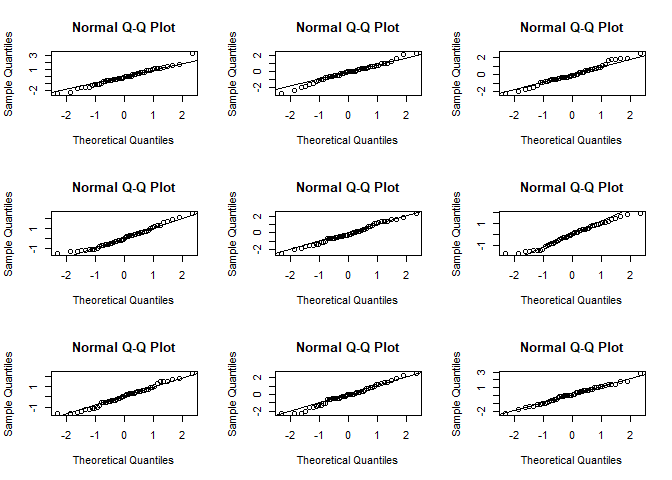

```r
par(mfrow=c(3,3))
n <- 50
# normal
for(i in 1:9) {x <- rnorm(n) ; qqnorm(x) ; qqline(x)}
```

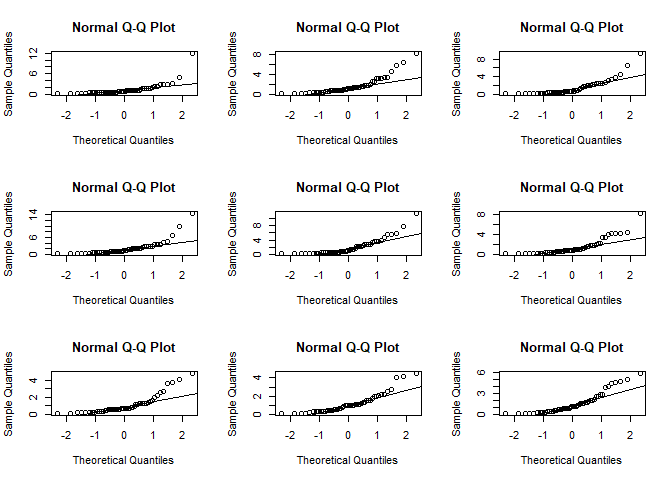

```r
# lognormal
for(i in 1:9) {x <- exp(rnorm(n)); qqnorm(x); qqline(x)}
```

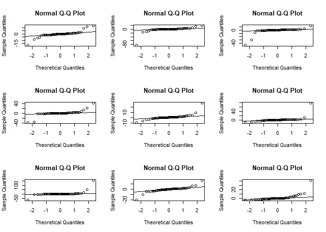

```r
# cauchy
for(i in 1:9) {x <- rcauchy(n); qqnorm(x); qqline(x)}
```

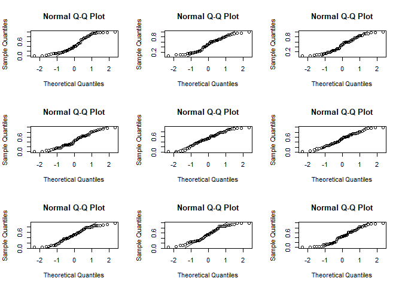

```r
# uniform
for(i in 1:9) {x <- runif(n); qqnorm(x); qqline(x)}
```

```r
par(mfrow=c(1,1))
shapiro.test(residuals(model))
```

```
##
##  Shapiro-Wilk normality test
##
## data:  residuals(model)
## W = 0.97976, p-value = 0.5421
```

El gráfico de los datos es:

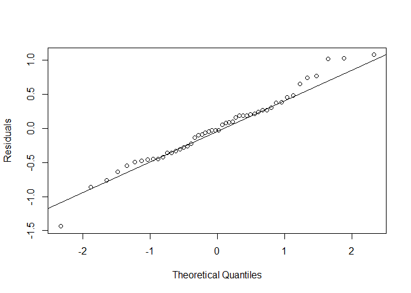

```r
qqnorm(residuals(model), ylab = "Residuals", main = "")
qqline(residuals(model))
```

Los puntos siguen la línea, aunue los puntos en el extremo derecho se alejan un poco de la línea, podría ser distribución Cauchy (con colas pesadas). Aunque pueden ser outliers. Se podria intentar eliminar estos residuos a ver si siguen presentando diferencias los extremos o son outliers.

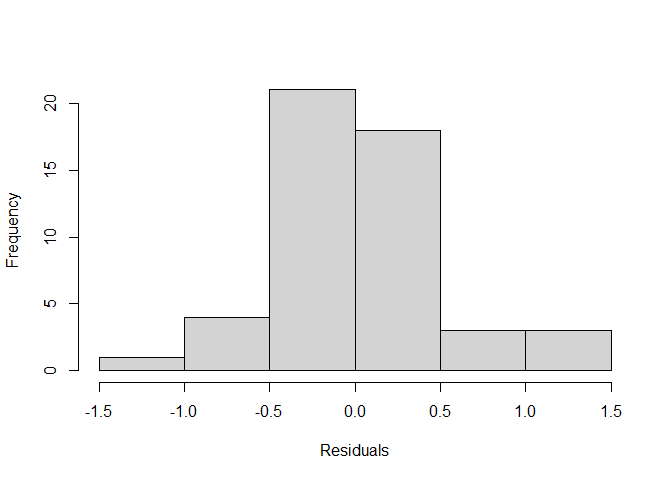

```r
hist(residuals(model),xlab="Residuals",main="")
```

```r
shapiro.test(residuals(model))
```

```
##
##  Shapiro-Wilk normality test
##
## data:  residuals(model)
## W = 0.97976, p-value = 0.5421
```

No se rechaza la hipótesis nula de normalidad.

3. Check for large leverage points.

Un leverage alto indica una varianza de residuos pequeña.

```r
hatv <- hatvalues(model)

sum(hatv)
```

```
## [1] 5
```

No esperamos una linea recta pero estamos buscando outliers, que serán puntos que divergen del resto.

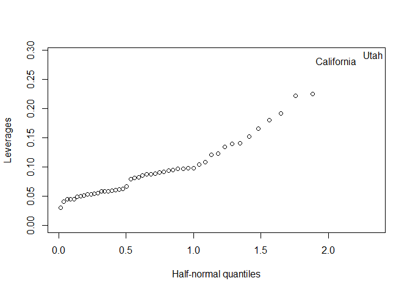

```r
estados <- row.names(sat)
halfnorm(hatv, labs = estados, ylab = "Leverages")
```

A continuacion voy a escalar los residuos y a usar los residuos estandarizados / estandarizados, pues se han estandaruzados para tener varinza igual (no pueden arreglar la heterocedasticidad como tal )

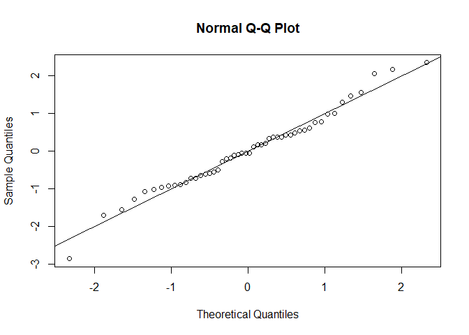

```r
qqnorm(rstandard(model))
abline(0,1)
```

4. Check for outliers.

```r
set.seed(123)
testdata <- data.frame(x=1:10,y=1:10+rnorm(10))
lmod <- lm(y ~ x, testdata)
```

En el primer ejemplo se añade un outlier con un valor predictor central

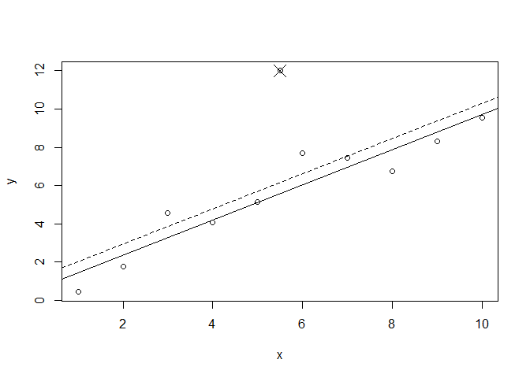

```r
p1 <- c(5.5,12)
lmod1 <- lm(y ~ x, rbind(testdata, p1))
plot(y ~ x, rbind(testdata, p1))
points(5.5, 12, pch=4, cex=2)
abline(lmod)
abline(lmod1, lty=2)
```

Este punto es un outlier pero no cambia sustancialmente la regresión

En el segundo ejemplo se añade un outlier con un valor predictor fuera del rango

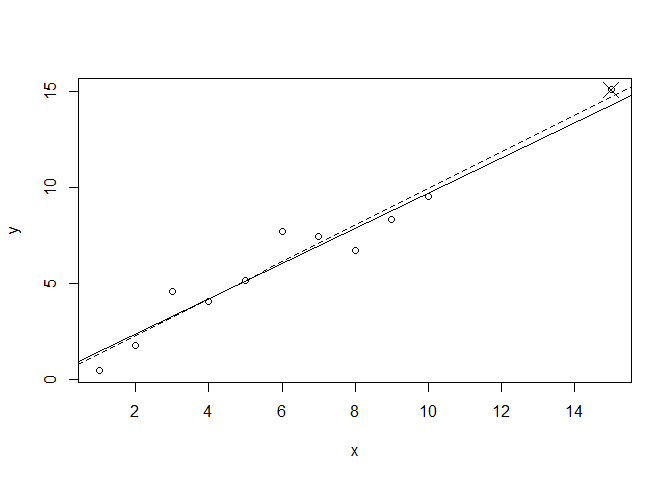

```r
p2 <- c(15,15.1)
lmod2 <- lm(y ~ x, rbind(testdata, p2))
plot(y ~ x, rbind(testdata, p2))
points(15, 15.1, pch=4, cex=2)
abline(lmod)
abline(lmod2, lty=2)
```

ESte punto provoca una ligera diferencia, pero no es outlier ni es influencial.

En el tercer caso se añade un tercer outlier (p3)

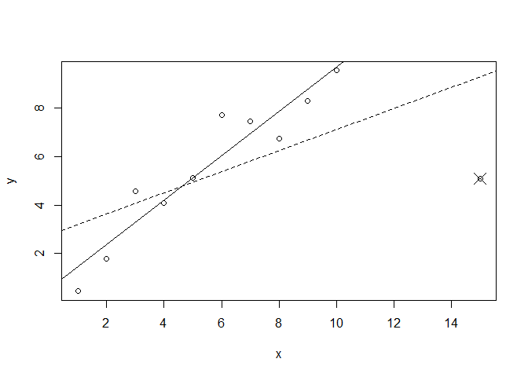

```r
p3 <- c(15,5.1)
lmod3 <- lm(y ~ x, rbind(testdata, p3))
plot(y ~ x, rbind(testdata, p3))
points(15, 5.1, pch=4, cex=2)
abline(lmod)
abline(lmod3, lty=2)
```

Este punto cambia la regresión subtancialmente Es un outlier y un punto substancial pues cambia los residuos paralos otrps puntos

Seleccionamos los outliers con mayores residuos y aplicamos la correción de Bonferroni para determinar si son outliers o no.

```r
stud <- rstudent(model)
stud[which.max(abs(stud))]
```

```
## West Virginia
##     -3.117753
```

Calculamos el valor critico de Bonferroni:

```r
qt(0.05/(50*2),44)
```

```
## [1] -3.525801
```

Como el valor absoluto del residuo es menor que el valor crítico, no se puede considerar un outlier.

5. Check for influential points.

Un punto influencial es aquel cuya eliminación produce un cambio sustancial en el modelo. Puede ser o no un outlier y tener o no un leverage grande, pero al menos suele tener una de las dos caracteristicas.

Los estadísticaos más conocidos son los Cooks:

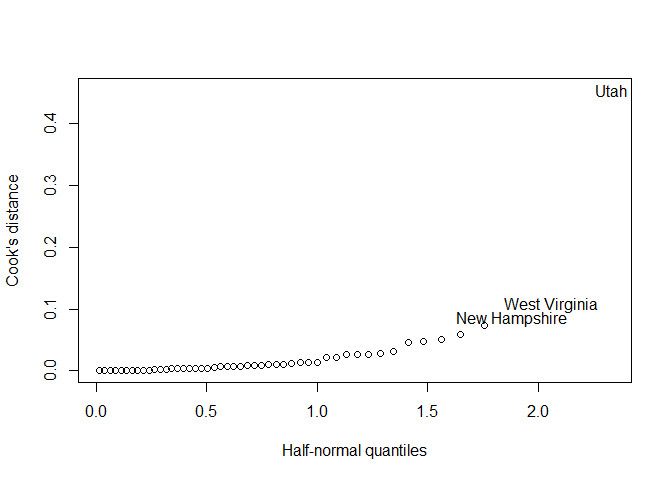

```r
cook <- cooks.distance(model)
halfnorm(cook, 3, labs = estados, ylab = "Cook's distance")
```

A continuación se eliminan los puntos con mayor influencia y se ajusta el modelo de nuevo.

```r
modeli <- lm(total ~ expend + salary + ratio + takers, data = sat, subset = (cook < max(cook)))
summary(modeli)
```

```
##
## Call:
## lm(formula = total ~ expend + salary + ratio + takers, data = sat,
##     subset = (cook < max(cook)))
##
## Residuals:
##     Min      1Q  Median      3Q     Max
## -92.118 -18.402   1.808  14.890  67.669
##
## Coefficients:
##              Estimate Std. Error t value Pr(>|t|)
## (Intercept) 1093.8460    53.4226  20.475   <2e-16 ***
## expend        -0.9427    10.1922  -0.092    0.927
## salary         3.0964     2.3283   1.330    0.190
## ratio         -7.6391     3.4279  -2.229    0.031 *
## takers        -2.9308     0.2188 -13.397   <2e-16 ***
## ---
## Signif. codes:  0 '***' 0.001 '**' 0.01 '*' 0.05 '.' 0.1 ' ' 1
##
## Residual standard error: 30.9 on 44 degrees of freedom
## Multiple R-squared:  0.8396, Adjusted R-squared:  0.825
## F-statistic: 57.58 on 4 and 44 DF,  p-value: < 2.2e-16
```

```r
summary(model)
```

```
##
## Call:
## lm(formula = sqrt(total) ~ expend + salary + ratio + takers,
##     data = sat)
##
## Residuals:
##      Min       1Q   Median       3Q      Max
## -1.43610 -0.34707 -0.02486  0.25943  1.08084
##
## Coefficients:
##              Estimate Std. Error t value Pr(>|t|)
## (Intercept) 32.297536   0.840140  38.443   <2e-16 ***
## expend       0.075430   0.167592   0.450    0.655
## salary       0.026203   0.037935   0.691    0.493
## ratio       -0.056489   0.051095  -1.106    0.275
## takers      -0.046730   0.003675 -12.716   <2e-16 ***
## ---
## Signif. codes:  0 '***' 0.001 '**' 0.01 '*' 0.05 '.' 0.1 ' ' 1
##
## Residual standard error: 0.5197 on 45 degrees of freedom
## Multiple R-squared:  0.8278, Adjusted R-squared:  0.8125
## F-statistic: 54.08 on 4 and 45 DF,  p-value: < 2.2e-16
```

Por lo tanto, se observa una diferencia en la significancia de los coeficientes entre los dos modelos, lo que sugiere que la inclusión o exclusión de datos influyentes puede afectar la relación entre las variables predictoras y la variable de respuesta en el modelo de regresión.

Este gráfico muestra el cambio en el coeficiente para la variable predictora “expend” después de considerar la diferencia de los datos influentes utilizando la distancia de Cook. Cada punto en el gráfico representa la magnitud del cambio en el coeficiente para “expend” al excluir un punto de datos influyente

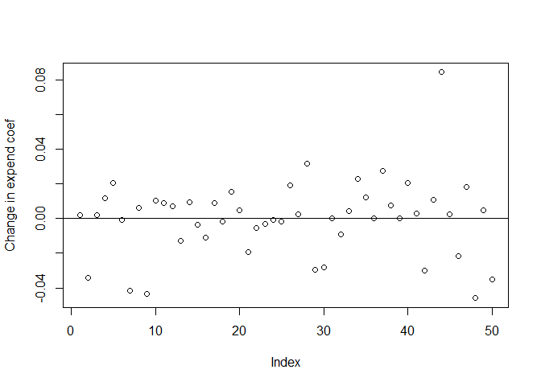

```r
plot(dfbeta(model)[,2],ylab = "Change in expend coef")
abline(h=0)
```

Vemos que hay varios puntos que cambiamn.

6. Check the structure of the relationship between the predictors and the response.

Podemos ver sugerencias de transformaciones de variables para mejorar la estructura de la relación entre las variables predictoras y la variable de respuesta en el modelo de regresión.

Construimos una regresion parcial

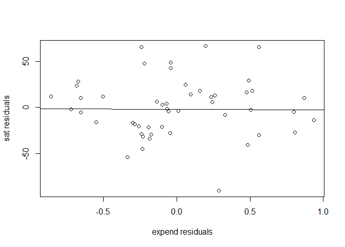

```r
d <- residuals(lm(total ~ expend + salary + ratio + takers, data = sat))
m <- residuals(lm(expend ~ salary + ratio + takers, data = sat))
plot(m, d, xlab = "expend residuals", ylab = "sat residuals")
abline(d, m)
```

```r
coef(lm(d ~m))
```

```
##   (Intercept)             m
##  1.381681e-15 -2.406107e-14
```

```r
coef(model)
```

```
## (Intercept)      expend      salary       ratio      takers
## 32.29753601  0.07543047  0.02620276 -0.05648875 -0.04672981
```

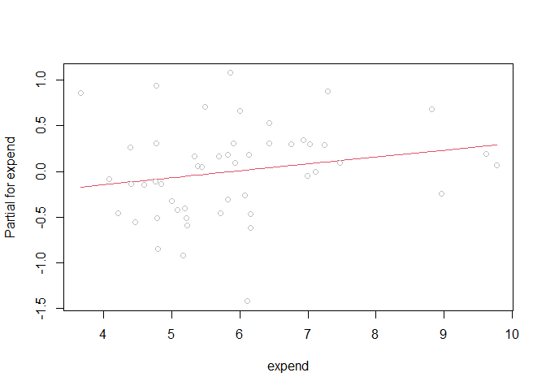

```r
termplot(model, partial.resid = T, terms = 1)
```

Se pueden apreciar dos grupos en el gráfico

```r
model1 <- lm(total ~ expend + salary + ratio + takers, data = sat, subset = (expend>6))
model2 <- lm(total ~ expend + salary + ratio + takers, data = sat, subset = (expend<6))
summary(model1)
```

```
##
## Call:
## lm(formula = total ~ expend + salary + ratio + takers, data = sat,
##     subset = (expend > 6))
##
## Residuals:
##     Min      1Q  Median      3Q     Max
## -59.818 -13.456   3.091  15.186  49.887
##
## Coefficients:
##             Estimate Std. Error t value Pr(>|t|)
## (Intercept) 994.7970    87.3748  11.385 1.83e-08 ***
## expend       -8.6936    14.2395  -0.611    0.551
## salary        4.0757     3.2329   1.261    0.228
## ratio        -2.8374     5.4074  -0.525    0.608
## takers       -2.2405     0.3276  -6.838 8.08e-06 ***
## ---
## Signif. codes:  0 '***' 0.001 '**' 0.01 '*' 0.05 '.' 0.1 ' ' 1
##
## Residual standard error: 28.69 on 14 degrees of freedom
## Multiple R-squared:  0.8209, Adjusted R-squared:  0.7697
## F-statistic: 16.04 on 4 and 14 DF,  p-value: 3.995e-05
```

```r
summary(model2)
```

```
##
## Call:
## lm(formula = total ~ expend + salary + ratio + takers, data = sat,
##     subset = (expend < 6))
##
## Residuals:
##     Min      1Q  Median      3Q     Max
## -50.233 -19.527  -5.211  12.643  79.212
##
## Coefficients:
##              Estimate Std. Error t value Pr(>|t|)
## (Intercept) 1017.9597    90.6421  11.231 2.93e-11 ***
## expend        18.7994    16.7715   1.121    0.273
## salary        -0.5454     3.2032  -0.170    0.866
## ratio         -1.6764     3.8813  -0.432    0.670
## takers        -3.2461     0.3297  -9.846 4.39e-10 ***
## ---
## Signif. codes:  0 '***' 0.001 '**' 0.01 '*' 0.05 '.' 0.1 ' ' 1
##
## Residual standard error: 32.26 on 25 degrees of freedom
## Multiple R-squared:  0.8506, Adjusted R-squared:  0.8267
## F-statistic: 35.59 on 4 and 25 DF,  p-value: 5.544e-10
```

En estos gráficos distinguimos dos grupos, uno con un gasto mayor a 6 y otro con un gasto menor a 6

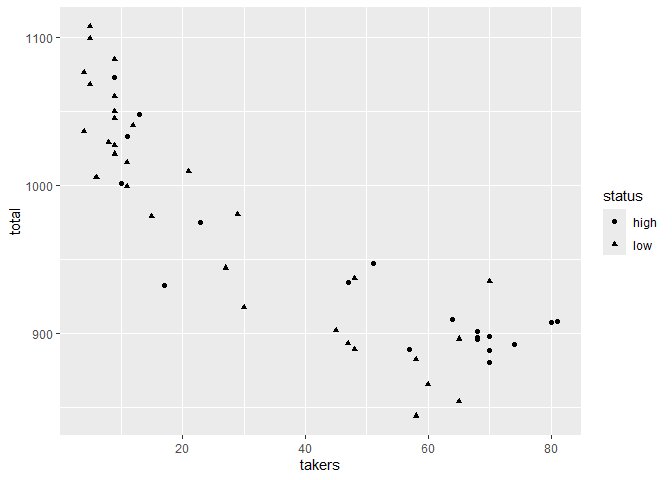

```r
sat$status <- ifelse(sat$expend > 6, "high", "low")
require(ggplot2)
ggplot(sat, aes(x = takers, y = total, shape = status)) +
  geom_point()
```

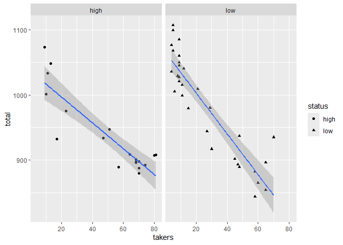

```r
ggplot(sat, aes(x = takers, y = total, shape = status)) +
  geom_point() +
  facet_grid(~ status) +
  stat_smooth(method = "lm")
```

2. (Ejercicio 2 cap. 6 pág. 97) Using the teengamb dataset, fit a model with gamble as the response and the other variables as predictors. Answer the questions posed in the previous question.
3. (Ejercicio 3 cap. 6 pág. 97) For the prostate data, fit a model with lpsa as the response and the other variables as predictors. Answer the questions posed in the first question.
4. (Ejercicio 4 cap. 6 pág. 97) For the swiss data, fit a model with Fertility as the response and the other variables as predictors. Answer the questions posed in the first question.
5. (Ejercicio 5 cap. 6 pág. 97) Using the cheddar data, fit a model with taste as the response and the other three variables as predictors. Answer the questions posed in the first question